# DATA Assessment 2023-24

## Department of Computer Science, University of York

### DATA: Introduction to Data Science

## Task 1: Domain Analysis (5 marks)

Given the business domain and the data overview presented (in the assessment paper), provide a brief description of

- the business problem and its significance to the relevant sector;
- the link between the business problem and the field of data science;
- the main areas of investigation; and
- potential ideas and solutions.

**Word Limit:** 300 words

**Write your answer here (text cell(s) to be used, as appropriate)**

The business problem within the financial sector revolves around optimizing customer service, risk assessment, and retention strategies. It's crucial due to the competitive landscape where personalized services and risk management are paramount. The link to data science is pivotal; leveraging client records, transaction histories, and demographic statistics allows for predictive modeling, risk profiling, and customer segmentation.

The main areas of investigation encompass customer behavior analysis, risk assessment, and retention strategy formulation. Understanding spending patterns, transaction frequencies, and account behaviors aids in predicting customer needs and identifying potential risks. Demographic data analysis helps in assessing regional financial stability and its impact on client behavior.

Potential solutions revolve around predictive modeling for risk assessment, segmentation to tailor services, and personalized retention strategies. Machine learning algorithms can predict potential risks based on transactional behavior, aiding in proactive risk management. Customer segmentation enables targeted offerings, enhancing satisfaction and retention. Additionally, leveraging financial behavior and demographic allows for region-specific strategies, incentivizing loyalty and improving service for financially stable customers.

In essence, employing data science techniques offers insights into customer behavior, risk factors, and regional dynamics, enabling proactive decision-making. This aligns with the bank's goal of improving services and ensuring prudent risk management while fostering long-term customer relationships.

```python
### Write your answer here (code cell(s) to be used, as appropriate)
```

## Task 2: Database Design (25 marks)

Having understood the business domain, present a conceptual design in the form of an entity-relationship (ER) model that would be helpful in creating a database for the bank.

The bank data currently exists in the form of a csv file called *BankRecords.csv*, provided on VLE (path given in page 5, assessment paper). This file has all the existing records. The table available in the csv file is unnormalised. The information about its different columns is given in Tables 1 and 2 (in the assessment paper).

Following the standard principles of database normalisation, normalise the given table (*BankRecords.csv*) to a database schema that has minimum redundancies. Then, using the designed schema, create an SQLite database.

Your answer should include the SQL statements needed to accomplish this step. Your submission should also include the created SQLite database file.

Your answer should clearly cover the following:

- Any assumptions you are making about the given scenario;
- The designated keys, existing relationships, and identified functional dependencies;
- The steps followed and justifications for the decisions made.

**World Limit**: 500 words. This limit applies only to the explanations. There is no limit on any associated code/SQL statements or figures.

**Write your answer here (text cell(s) to be used, as appropriate)**

According to the Top-Down approach of database normalisation process, the 1NF is already achieved as each cell of the database table contain only one value. Although it can be seen that there are lots of duplication of the same record throughout the columns and breaking down these records into their respective table results in the creation of tables residence, client, account, loan, order, transaction, lastly card.

First and foremost, it can be seen that the records regarding the residence or demographic of the client is partially dependent on account_id and client_id, hence, the creation of tables residence, client, and account as shown in Code 1, 2, and 3. The residence table aids in the simplification and redundancy avoidance for the client table as a client can be from the same place. The attributes of the residence table have been discriptively renamed to avoid confusion; for instance, a1 to city_id which is the primary key that fully determines the table's other attributes.

It is stated that a client may have multiple accounts and an account may have an owner and/or a disponent owner which creates a many-to-many relationship. In this case, the relationship becomes complex and it is crucial to introduce a junction table to convert the existing relationship into one-to-many between the client and the account table. The table disponent is established to mitigate the issue by having a primary key disp_id and foreign keys consist of client_id, and account_id as the linker to the other tables. Another key attribute for this table is the disp_type which tells if a client is an owner or a disponent. Now all the tables has achieved 2NF and it is normalised as the primary keys disp_id, client_id, and account_id fully determine the tables' other attributes respectively which achieves full functional dependency.

Populating the completed and normalised database is shown in Code 10.

The entity-relationship model is as shown below.

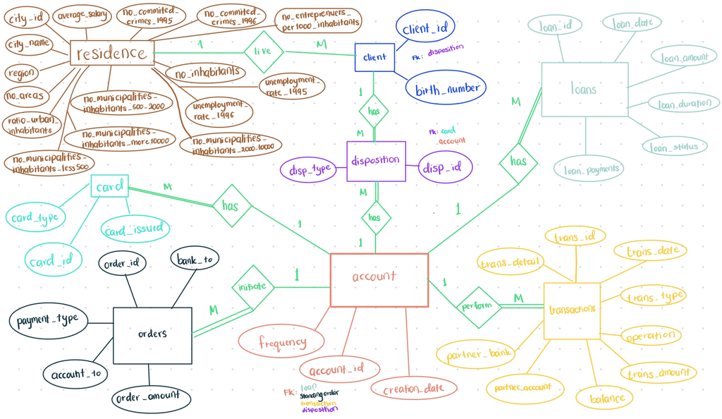

```python
### Write your answer here (code cell(s) to be used, as appropriate)

# Code 1: residence table creation
# CREATE TABLE residence (
# 	city_id INT NOT NULL PRIMARY KEY,
# 	city_name VARCHAR,
# 	region VARCHAR,
# 	no_inhabitants INT,
# 	no_areas INT,
# 	average_salary INT,
# 	ratio_urban_inhabitants DECIMAL,
# 	unemployment_rate_1995 DECIMAL,
# 	unemployment_rate_1996 DECIMAL,
# 	no_entrepreneurs_per1000_inhabitants INT,
# 	no_commited_crimes_1995 INT,
# 	no_commited_crimes_1996 INT,
# 	no_municipalities_inhabitations_less500 INT,
# 	no_municipalities_inhabitations_500_2000 INT,
# 	no_municipalities_inhabitations_2000_10000 INT,
# 	no_municipalities_inhabitations_more10000 INT
# );

# # Code 2: client table creation
# CREATE TABLE client (
# 	client_id INT NOT NULL PRIMARY KEY,
# 	birth_number varchar,
# 	city_id INT,
# 	FOREIGN KEY (city_id) REFERENCES residence(city_id)
# );

# # Code 3: account table creation
# CREATE TABLE account (
# 	account_id INT NOT NULL PRIMARY KEY,
# 	disp_id INT,
# 	creation_date varchar,
# 	frequency varchar
# );

# # Code 4: disposition table creation
# CREATE TABLE disposition (
# 	disp_id INT NOT NULL PRIMARY KEY,
# 	client_id INT NOT NULL,
# 	account_id INT NOT NULL,
# 	disp_type VARCHAR,
# 	FOREIGN KEY (client_id) REFERENCES client(client_id),
# 	FOREIGN KEY (account_id) REFERENCES account(account_id)
# );

# # Code 6: transactions table creation
# CREATE TABLE transactions (
# 	trans_id INT NOT NULL PRIMARY KEY,
# 	account_id INT,
# 	trans_detail VARCHAR,
# 	trans_date varchar,
# 	trans_type varchar,
# 	trans_amount DECIMAL,
# 	operation varchar,
# 	balance DECIMAL,
# 	partner_account INT,
# 	partner_bank VARCHAR(2),
# 	FOREIGN KEY (account_id) REFERENCES account(account_id)
# );

# # Code 7: orders table creation
# CREATE TABLE orders (
# 	order_id INT NOT NULL PRIMARY KEY,
# 	account_id INT,
# 	bank_to varchar(2),
# 	account_to INT,
# 	order_amount DECIMAL,
# 	payment_type varchar,
# 	FOREIGN KEY (account_id) REFERENCES account(account_id)
# );

# # Code 8: loans table creation
# CREATE TABLE loans (
# 	loan_id INT PRIMARY KEY,
# 	account_id INT,
# 	loan_date varchar,
# 	loan_amount DECIMAL,
# 	loan_duration INT,
# 	loan_status varchar(1),
# 	loan_payments DECIMAL,
# 	FOREIGN KEY (account_id) REFERENCES account(account_id)
# );

# # Code 9: card table creation
# CREATE TABLE card (
# 	card_id INT NOT NULL PRIMARY KEY,
#  	disp_id INT,
# 	card_issued varchar,
# 	card_type varchar,
# 	FOREIGN KEY (disp_id) REFERENCES disposition(disp_id)
# );


# # Code 10: data insertion
# INSERT INTO residence (city_id, city_name, region, no_inhabitants,
# no_municipalities_inhabitations_less500,
# no_municipalities_inhabitations_500_2000,
# no_municipalities_inhabitations_2000_10000,
# no_municipalities_inhabitations_more10000,
# no_areas,
# ratio_urban_inhabitants,
# average_salary,
# unemployment_rate_1995,
# unemployment_rate_1996,
# no_entrepreneurs_per1000_inhabitants,
# no_commited_crimes_1995,
# no_commited_crimes_1996)
# SELECT DISTINCT field31, field32, field33, field34, field35, field36, field37, field38, field39, field40, field41, field42, field43, field44, field45, field46
# FROM BankRecords
# WHERE field1 NOT IN (SELECT field1 FROM BankRecords LIMIT 1);


# INSERT INTO client (client_id, birth_number, city_id)
# SELECT DISTINCT field25, field30, field31
# FROM BankRecords
# WHERE field1 NOT IN (SELECT field1 FROM BankRecords LIMIT 1);


# INSERT INTO account (account_id, frequency, creation_date)
# SELECT DISTINCT field1, field2, field3
# FROM BankRecords
# WHERE field1 NOT IN (SELECT field1 FROM BankRecords LIMIT 1) AND field1 IS NOT NULL;


# INSERT INTO disposition (disp_id, client_id, account_id, disp_type)
# SELECT DISTINCT field24, field25, field1, field26
# FROM BankRecords
# WHERE field1 NOT IN (SELECT field1 FROM BankRecords LIMIT 1) AND field24 IS NOT NULL;


# INSERT INTO loans (account_id, loan_id, loan_date, loan_amount, loan_duration, loan_payments, loan_status)
# SELECT DISTINCT field1, field4, field5, field6, field7, field8, field9
# FROM BankRecords
# WHERE field1 NOT IN (SELECT field1 FROM BankRecords LIMIT 1) AND field4 IS NOT NULL;


# INSERT INTO orders (account_id, order_id, bank_to, account_to, order_amount, payment_type)
# SELECT DISTINCT field1, field10, field11, field12, field13, field14
# FROM BankRecords
# WHERE field1 NOT IN (SELECT field1 FROM BankRecords LIMIT 1) AND field10 IS NOT NULL;


# INSERT INTO transactions (account_id, trans_id, trans_date, trans_type, operation, trans_amount, balance, trans_detail, partner_bank, partner_account)
# SELECT DISTINCT field1, field15, field16, field17, field18, field19, field20, field21, field22, field23
# FROM BankRecords
# WHERE field1 NOT IN (SELECT field1 FROM BankRecords LIMIT 1) AND field15 IS NOT NULL;


# INSERT INTO card (disp_id, card_id, card_type, card_issued)
# SELECT DISTINCT field24, field27, field28, field29
# FROM BankRecords
# WHERE field1 NOT IN (SELECT field1 FROM BankRecords LIMIT 1) AND field27 IS NOT NULL;
```

## Task 3: Research Design (25 Marks)

Using the database designed in Task 2, design and implement **five** potential modelling solutions to achieve the aim of the Data Intelligence team. You need to provide clear justifications about the techniques selected in the context of the 'problem in hand'. Your design must consist of a combination of inferential statistics, supervised learning algorithms, and unsupervised learning algorithms, and include **at least one** of those techniques. Finally, your modelling solutions should be of sufficient complexity, combining information from multiple tables from the database built in Task 2, as appropriate. Your answer should clearly show the queries made to the database. If amendments are made to the database, the commands should be clearly included in your answer.

Your answer should clearly cover the following:

- Any assumptions you are making about the given scenario;
- Any data processing and data integrity steps you would undertake to make the data fit for purpose;
- Which technique(s) you would apply for each solution and why;
- An evaluation of the techniques applied in terms of the accuracy of their results (or any other suitable evaluation measure);
- Algorithmic parameters should be adequately stated and discussed;
- A discussion of ethical considerations arising from the solutions selected.

**World Limit**: 500 words. This limit applies only to the explanations. There is no limit on any associated code or figures.

**Write your answer here (text cell(s) to be used, as appropriate)**

```python
### Write your answer here (code cell(s) to be used, as appropriate)
import pandas as pd
import numpy as np
import sqlite3

# load the data through the db file
fileDB  = "BankRecords_Normalised.db"
```

```python
#Connect to DB
def create_connection(path):
    connection = None
    try:
        connection = sqlite3.connect(path)
        print("Connection to SQLite DB successful")
    except IOError as e:
        print(f"The error '{e}' occurred")
    return connection

connection = create_connection(fileDB)
```

```
Connection to SQLite DB successful
```

### Modelling Solution 1: Unsupervised Learning (K-means Clustering with PCA)

```python
#Load data from DB using Pandas read_sql_query()
loadQuery  = """
SELECT
    t.account_id,
	AVG(trans_amount) AS avg_transaction_amount,
	SUM(CASE WHEN trans_type = 'Withdrawal' THEN trans_amount ELSE 0 END) AS total_withdrawal,
	SUM(CASE WHEN trans_type = 'Credit' THEN trans_amount ELSE 0 END) AS total_credit,
	l.loan_amount,
	l.loan_duration
FROM
	transactions t
JOIN
	loans l ON t.account_id = l.account_id
GROUP BY t.account_id;
"""

dfDB = pd.read_sql_query(sql=loadQuery, con=connection)
dfDB.head()
```

|  | account_id | avg_transaction_amount | total_withdrawal | total_credit | loan_amount | loan_duration |
| --- | --- | --- | --- | --- | --- | --- |
| 0 | 2 | 6593.052929 | 1336983.8 | 1597053.5 | 80952 | 24 |
| 1 | 19 | 5199.722442 | 750127.3 | 793194.6 | 30276 | 12 |
| 2 | 25 | 10797.609854 | 1378415.0 | 1494372.1 | 30276 | 12 |
| 3 | 37 | 7293.491538 | 409469.7 | 497029.2 | 318480 | 60 |
| 4 | 38 | 4399.613077 | 225865.4 | 308265.3 | 110736 | 48 |

```python
# Check for duplicate records
duplicatesNum = dfDB.duplicated().sum()
print("There are %d duplicate records"% (duplicatesNum))
# df.duplicated()

# Check for Null value attributes
isNaNum = dfDB.isna().sum()
print(isNaNum)
```

```
There are 0 duplicate records
account_id                0
avg_transaction_amount    0
total_withdrawal          0
total_credit              0
loan_amount               0
loan_duration             0
dtype: int64
```

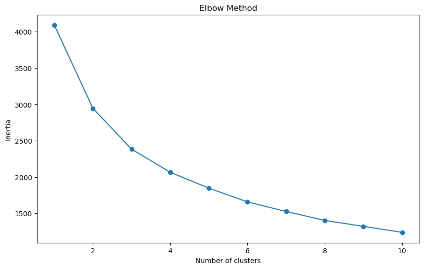

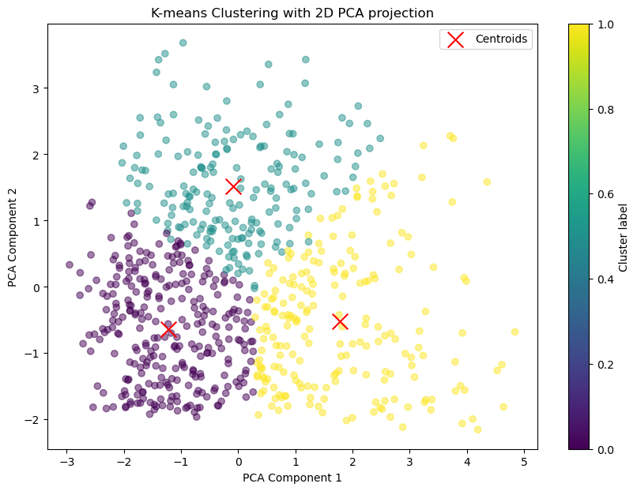

```python
import pandas as pd
from sklearn.cluster import KMeans
from sklearn.preprocessing import StandardScaler
from sklearn.decomposition import PCA
import matplotlib.pyplot as plt
import warnings
warnings.filterwarnings("ignore")

# The attributes extracted are relevant because they provide a comprehensive view of customer financial behavior.
# Average transaction amount: Gives insight into spending habits
# Total withdrawals and credits: Reflect cash flow patterns
# Loan amount and duration: Indicate borrowing behavior and financial commitments
# Together these attributes paint a detailed picture of each customer’s financial profile,
# which is critical for segmenting customers based on their banking activities, risk levels, and potential for
# targeted product offerings. These financial indicators are core to understanding customer behavior in the banking sector.

# Standardize the features
scaler = StandardScaler()
scaled_features = scaler.fit_transform(dfDB)

# Determine the optimal number of clusters using the Elbow Method
inertia = []
for k in range(1, 11):
    kmeans = KMeans(n_clusters=k, random_state=42)
    kmeans.fit(scaled_features)
    inertia.append(kmeans.inertia_)

# Plotting the Elbow Method graph
plt.figure(figsize=(10, 6))
plt.plot(range(1, 11), inertia, marker='o')
plt.title('Elbow Method')
plt.xlabel('Number of clusters')
plt.ylabel('Inertia')
plt.show()

# Choose the appropriate number of clusters based on the elbow method
kmeans_optimal = KMeans(n_clusters=3, random_state=42)
kmeans_optimal.fit(scaled_features)

# Get the cluster labels and centroids
clusters = kmeans_optimal.labels_
centroids = kmeans_optimal.cluster_centers_


# Using PCA to reduce the data to two components for visualization using 2D Scatter plot
pca = PCA(n_components=2)
reduced_features = pca.fit_transform(scaled_features)

# Project the centroids onto the same PCA space as the data
centroids_pca = pca.transform(centroids)

# Scatter plot of the two PCA components colored by cluster labels
plt.figure(figsize=(10, 7))
plt.scatter(reduced_features[:, 0], reduced_features[:, 1], c=clusters, cmap='viridis', marker='o', alpha=0.5)

# Plot the centroids
plt.scatter(centroids_pca[:, 0], centroids_pca[:, 1], marker='x', s=200, c='red', label='Centroids')

# Labeling and visual layout
plt.title('K-means Clustering with 2D PCA projection')
plt.xlabel('PCA Component 1')
plt.ylabel('PCA Component 2')
plt.colorbar(label='Cluster label')
plt.legend()

plt.show()
```

### Modelling Solution 2: Supervised Learning (Decision Tree Classification)

As for the second modelling solution, in a banking scenario, predicting loan default is a common supervised learning problem where historical data can be used to train a model to make predictions on new clients. Decision Trees is chosen for its interpretability, which is crucial in a banking context where decisions need to be explained and justified which a well-performing model can assist in identifying high-risk clients. Algorithmic parameters include tree depth, feature selection criteria, and leaf node conditions. Proper tuning balances model complexity and predictive accuracy. Ensuring fairness and avoiding discriminatory features in model training are critical ethical considerations.

```python
#Load data from DB using Pandas read_sql_query()
loadQuery  = """
SELECT DISTINCT
    a.account_id,
    a.creation_date,
    a.frequency,
    r.average_salary,
    r.unemployment_rate_1995,
    r.no_commited_crimes_1995,
    l.loan_amount,
    l.loan_duration,
    l.loan_payments,
    l.loan_status
FROM
    account a
JOIN
    loans l ON a.account_id = l.account_id
JOIN
    disposition d ON a.account_id = d.account_id
JOIN
    client c ON d.client_id = c.client_id
JOIN
    residence r ON c.city_id = r.city_id
WHERE
    l.loan_date BETWEEN '950101' AND '951231';
"""

dfDB = pd.read_sql_query(sql=loadQuery, con=connection)
dfDB.head()
```

|  | account_id | creation_date | frequency | average_salary | unemployment_rate_1995 | no_commited_crimes_1995 | loan_amount | loan_duration | loan_payments | loan_status |
| --- | --- | --- | --- | --- | --- | --- | --- | --- | --- | --- |
| 0 | 347 | 931213 | Monthly | 12541 | 0.29 | 85677 | 187224 | 24 | 7801 | B |
| 1 | 789 | 950206 | Monthly | 10446 | 7.34 | 4947 | 73056 | 48 | 1522 | C |
| 2 | 816 | 930805 | Monthly | 9317 | 6.49 | 6949 | 48624 | 24 | 2026 | A |
| 3 | 817 | 940318 | Monthly | 9307 | 3.85 | 2616 | 538500 | 60 | 8975 | C |
| 4 | 854 | 930921 | Monthly | 12541 | 0.29 | 85677 | 87216 | 48 | 1817 | C |

```python
# Check for duplicate records
duplicatesNum = dfDB.duplicated().sum()
# print(dfDB.describe)
print("There are %d duplicate records"% (duplicatesNum))
# df.duplicated()

# Check for Null value attributes
isNaNum = dfDB.isna().sum()
print(isNaNum)
```

```
There are 0 duplicate records
account_id                 0
creation_date              0
frequency                  0
average_salary             0
unemployment_rate_1995     0
no_commited_crimes_1995    0
loan_amount                0
loan_duration              0
loan_payments              0
loan_status                0
dtype: int64
```

```
Accuracy: 0.89
              precision    recall  f1-score   support

           0       0.82      1.00      0.90         9
           1       1.00      0.78      0.88         9

    accuracy                           0.89        18
   macro avg       0.91      0.89      0.89        18
weighted avg       0.91      0.89      0.89        18
```

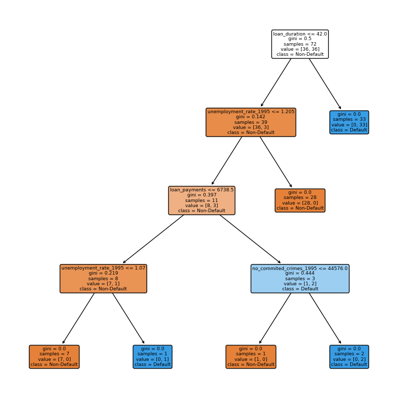

```python
# Using a classification algorithm to predict whether a client is likely to default on a loan in the year 1995.

from sklearn.model_selection import train_test_split
from sklearn.tree import DecisionTreeClassifier, plot_tree
from sklearn.metrics import accuracy_score, classification_report
import matplotlib.pyplot as plt_solution2

# Selecting relevant features and target variable
# The features selected for this model are relevant because they directly relate to a client's financial stability and their ability to repay a loan, which are critical factors in assessing credit risk:
# Average Salary: Higher salaries typically indicate a greater ability to make loan payments, reducing the likelihood of default.
# Unemployment Rate: Reflects the job market stability. Higher unemployment rates can increase the risk of borrowers defaulting if they lose their income source.
# Number of Committed Crimes: This can be an indirect indicator of socio-economic stability within a region. Higher crime rates might correlate with higher default rates due to economic distress.
# Loan Amount: Larger loans represent a higher financial burden on the borrower, potentially increasing the default risk.
# Loan Duration: Longer loan terms can increase uncertainty about a borrower's future ability to pay.
# Loan Payments: The size of loan payments relative to the borrower's income can affect their capacity to maintain regular payments.
# Each feature offers insight into the risk profile of a borrower, and when combined, they provide a comprehensive view of the likelihood that a borrower might default on a loan.
features = ['average_salary', 'unemployment_rate_1995', 'no_commited_crimes_1995', 'loan_amount', 'loan_duration', 'loan_payments']
target = 'loan_status'

# Extracting selected features and target variable
X = dfDB[features]
y = dfDB[target]

# Converting 'loan_status' to binary (0 for non-default, 1 for default)
y = y.apply(lambda x: 0 if x == 'A' else 1)

# Splitting the data into training and testing sets
X_train, X_test, y_train, y_test = train_test_split(X, y, test_size=0.2, random_state=42)

# Building and training the Decision Tree model
dt_classifier = DecisionTreeClassifier(random_state=42)
dt_classifier.fit(X_train, y_train)

# Predicting on the test set
y_pred = dt_classifier.predict(X_test)

# Evaluating the model
accuracy = accuracy_score(y_test, y_pred)
print(f'Accuracy: {accuracy:.2f}')

# Displaying classification report for more detailed evaluation
classification_report_solution2 = classification_report(y_test, y_pred)
print(classification_report_solution2)

# Visualizing the Decision Tree
plt_solution2.figure(figsize=(10, 10))
plot_tree(dt_classifier, filled=True, feature_names=features, class_names=['Non-Default', 'Default'], rounded=True)
plt_solution2.show()
```

### Modelling Solution 3: Inferential Statistics

Moving on to the third modelling solution, Inferential Statistics is employed to assess whether observed differences in transaction amounts between clients with and without loan defaults are statistically significant, providing insights into financial behavior associated with loan risk. The t-test helps determine if the observed differences are likely due to chance, contributing to robust decision-making. Its accuracy is contingent on assumptions like normality and independence. In terms of algorithmic parameters, critical parameters include sample sizes, and degrees of freedom. Proper calculation and understanding of t and p values are crucial for valid statistical inferences. As for the ethical consideration, ensuring data privacy and avoiding biases in sample selection are paramount. Transparent communication about statistical interpretations and limitations is necessary for ethical decision-making.

```python
#Load data from DB using Pandas read_sql_query()
loadQuery  = """
SELECT DISTINCT
    a.account_id,
    t.trans_date,
    t.trans_amount,
    l.loan_status
FROM
    transactions t
JOIN
    account a ON t.account_id = a.account_id
JOIN
    loans l ON a.account_id = l.account_id;
"""

dfDB = pd.read_sql_query(sql=loadQuery, con=connection)
dfDB.head()
```

|  | account_id | trans_date | trans_amount | loan_status |
| --- | --- | --- | --- | --- |
| 0 | 2 | 930226 | 1100.0 | A |
| 1 | 2 | 930312 | 20236.0 | A |
| 2 | 2 | 930328 | 3700.0 | A |
| 3 | 2 | 930331 | 13.5 | A |
| 4 | 2 | 930412 | 20236.0 | A |

```python
# Check for duplicate records
duplicatesNum = dfDB.duplicated().sum()
print("There are %d duplicate records"% (duplicatesNum))
# duplicates = dfDB[(dfDB.duplicated())]
# duplicates

# Check for Null value attributes
isNaNum = dfDB.isna().sum()
print(isNaNum)

# Drop irrelevant data
dfDB = dfDB.drop(columns=['account_id', 'trans_date'])
```

```
There are 0 duplicate records
account_id      0
trans_date      0
trans_amount    0
loan_status     0
dtype: int64
```

```python
# Performing a hypothesis test to determine if there is a significant difference in the average transaction amounts between
# clients who default on loans (loan_status = 1) and those who do not (loan_status = 0).
# This could provide insights into whether certain financial behaviors are associated with a higher risk of loan default.

# Null hypothesis and alternative hypothesis
# H0: There is no significant difference in the average transaction amounts between clients who default on loans and those who do not.
# H1: There is a significant difference in the average transaction amounts between clients who default on loans and those who do not.

from scipy.stats import ttest_ind, t
import numpy as np

# Converting 'loan_status' to binary (0 for non-default, 1 for default)
dfDB['loan_status'] = dfDB['loan_status'].apply(lambda x: 0 if x == 'A' else 1)

# Selecting relevant data for the test
# The data selected for this model, encompassing transaction amounts, and loan status are relevant for several key reasons:
# Transaction Amounts: They provide direct insight into the spending and saving behaviors of clients. Large or frequent transactions, whether deposits or withdrawals, can indicate financial stability or distress, respectively.
# Loan Status: This is a crucial variable for the bank, as it directly indicates whether a client has defaulted on a loan or not.
# By comparing transaction behaviors of clients with different loan statuses, the bank can identify patterns that may predict loan default risk.
default_transactions = dfDB[dfDB['loan_status'] == 1]['trans_amount']
non_default_transactions = dfDB[dfDB['loan_status'] == 0]['trans_amount']

# Sample sizes
sample_size1 = len(default_transactions)
sample_size2 = len(non_default_transactions)

# Standard deviation for each group
# s1 = np.std(default_transactions)
# s2 = np.std(non_default_transactions)

# Degrees of freedom
dof = sample_size1 + sample_size2 - 2

# Performing a two-tailed critical t-value test at a 95% confidence level
alpha = 0.05
t_crit = t.ppf(alpha/2, dof)


# Performing a two-sample independent t-test
t_stat, p_value = ttest_ind(default_transactions, non_default_transactions, equal_var=False)
```

```python
# Creating plot diagram
import matplotlib.pyplot as plt
import seaborn as sns
import numpy as np
from scipy import stats

def plotKDE(dof, tstatistic, title, xaxis, alpha=0.05, type='two-tailed'):
  fig = plt.figure(figsize=(5,4), dpi=100)
  mu =0
  data = np.random.standard_t(dof, size=3000)
  ax = sns.kdeplot(data)

  xx = ax.lines[-1].get_xdata()
  yy = ax.lines[-1].get_ydata()

  if (type=="two-tailed"):
    xxCut1 = stats.t.ppf(q=alpha/2, df=dof)
    ax.fill_between(xx, 0, yy, where=(xx<=xxCut1), color='red', alpha=0.5)
    ax.axvline(x=xxCut1, ymin=0.00, ymax=np.max(yy), color='red',alpha=0.5, ls='--', lw=1, label='Critical value') # vertical line
    ax.axvline(x=tstatistic, ymin=0.00, ymax=np.max(yy), color='blue',alpha=0.5, ls='--', lw=1, label='t value') # vertical line

    xxCut2 = stats.t.ppf(q=1-alpha/2, df=dof)
    ax.fill_between(xx, 0, yy, where=(xx>=xxCut2), color='red', alpha=0.5)
    ax.axvline(x=xxCut2, ymin=0.00, ymax=np.max(yy), color='red',alpha=0.5, ls='--', lw=1) # vertical line
    ax.axvline(x=-tstatistic, ymin=0.00, ymax=np.max(yy), color='blue',alpha=0.5, ls='--', lw=1) # vertical line

  elif (type=='left-tailed'):
    xxCut1 = stats.t.ppf(q=alpha, df=dof)
    ax.fill_between(xx, 0, yy, where=(xx<=xxCut1), color='red', alpha=0.5)
    ax.axvline(x=xxCut1, ymin=0.00, ymax=np.max(yy), color='red',alpha=0.5, ls='--', lw=1, label='Critical value') # vertical line
    ax.axvline(x=tstatistic, ymin=0.00, ymax=np.max(yy), color='blue',alpha=0.5, ls='--', lw=1, label='t value') # vertical line

  elif (type=='right-tailed'):
    xxCut2 = stats.t.ppf(q=1-alpha, df=dof)
    ax.fill_between(xx, 0, yy, where=(xx>=xxCut2), color='red', alpha=0.5)
    ax.axvline(x=xxCut2, ymin=0.00, ymax=np.max(yy), color='red',alpha=0.5, ls='--', lw=1,label='Critical value') # vertical line
    ax.axvline(x=tstatistic, ymin=0.00, ymax=np.max(yy), color='blue',alpha=0.5, ls='--', lw=1, label='t value') # vertical line

  plt.title(title,fontsize=15)
  ax.set_xlabel(xaxis,fontsize=13) # set x label
  ax.set_ylabel('pdf(x)',fontsize=13,rotation=90) # set y label
  plt.legend();
```

```
Degrees of Freedom: 190851
Two-tailed Critical t-value: -1.95997641458244
T-statistic: -0.37
P-value: 0.7139
Fail to reject the null hypothesis. (|t| = 0.3666 ≤ Critical t = 1.9600)
Fail to reject the null hypothesis. (p-value = 0.7139 ≥ alpha = 0.05)
```

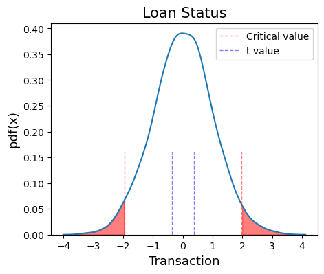

```python
# Drawing conclusions

# Displaying the values
print(f'Degrees of Freedom: {dof}')
print(f'Two-tailed Critical t-value: {t_crit}')
print(f'T-statistic: {t_stat:.2f}')
print(f'P-value: {p_value:.4f}')

# Comparison between absolute t value and critical t value
if np.abs(t_stat) > np.abs(t_crit):
    conclusion_t_value = f"Reject the null hypothesis. (|t| = {np.abs(t_stat):.4f} > Critical t = {np.abs(t_crit):.4f})"
else:
    conclusion_t_value = f"Fail to reject the null hypothesis. (|t| = {np.abs(t_stat):.4f} ≤ Critical t = {np.abs(t_crit):.4f})"
print(conclusion_t_value)

# Comparison between p value and alpha significance level
alpha = 0.05
if p_value < alpha:
    conclusion_p_value = f"Reject the null hypothesis. (p-value = {p_value:.4f} < alpha = {alpha})"
else:
    conclusion_p_value = f"Fail to reject the null hypothesis. (p-value = {p_value:.4f} ≥ alpha = {alpha})"
print(conclusion_p_value)

# Visualize the data
plotKDE(dof, t_stat, "Loan Status", "Transaction", type="two-tailed")
```

With significance level alpha=0.05, dof=190851 (two-tailed): t_crit = ±1.960

The t statistic result is 0.37 < 1.960

- We cannot reject H0
- There is statistically no significant difference in the average transaction amounts between clients who default on loans and those who do not.

### Modelling Solution 4: Supervised Learning (Decision Tree Classification)

```python
#Load data from DB using Pandas read_sql_query()
loadQuery = """
SELECT
    a.account_id,
    COUNT(t.trans_id) AS total_trans,
    AVG(t.trans_amount) AS avg_trans_amount,
    AVG(t.balance) AS avg_balance,
    l.loan_amount,
    l.loan_payments,
    cc.card_type
    FROM transactions t
JOIN
    disposition d ON t.account_id = d.account_id
JOIN
    card cc ON d.disp_id = cc.disp_id
JOIN
    account a ON d.account_id = a.account_id
JOIN
    loans l ON d.account_id = l.account_id
GROUP
    BY a.account_id;
"""

dfDB = pd.read_sql_query(sql=loadQuery, con=connection)
dfDB.head()
```

|  | account_id | total_trans | avg_trans_amount | avg_balance | loan_amount | loan_payments | card_type |
| --- | --- | --- | --- | --- | --- | --- | --- |
| 0 | 97 | 274 | 4486.337226 | 39814.610949 | 102876 | 8573 | classic |
| 1 | 105 | 59 | 8368.811864 | 30200.596610 | 352704 | 7348 | classic |
| 2 | 110 | 209 | 6839.223445 | 45365.278469 | 162576 | 4516 | classic |
| 3 | 132 | 198 | 12807.854040 | 52603.140404 | 88440 | 7370 | classic |
| 4 | 226 | 129 | 7233.487597 | 49698.993798 | 109344 | 9112 | classic |

```python
# Check for duplicate records
duplicatesNum = dfDB.duplicated().sum()
print("There are %d duplicate records"% (duplicatesNum))
# df.duplicated()

# Handling missing values
# dfDB.fillna(0, inplace=True)

# Check for Null value attributes
isNaNum = dfDB.isna().sum()
print(isNaNum)
```

```
There are 0 duplicate records
account_id          0
total_trans         0
avg_trans_amount    0
avg_balance         0
loan_amount         0
loan_payments       0
card_type           0
dtype: int64
```

```
Accuracy: 0.88
Classification Report:
              precision    recall  f1-score   support

           0       0.20      1.00      0.33         1
           1       1.00      0.88      0.94        33

    accuracy                           0.88        34
   macro avg       0.60      0.94      0.63        34
weighted avg       0.98      0.88      0.92        34
```

[figure not shown]

```python
# Classify clients based on their transaction history and loan information to determine the appropriate card type

from sklearn.model_selection import train_test_split
from sklearn.tree import DecisionTreeClassifier, plot_tree
from sklearn.metrics import accuracy_score, classification_report, precision_score, recall_score, f1_score
import pandas as pd
import matplotlib.pyplot as plt_solution4

# Selecting relevant features and target variable
# The features selectedare relevant because they provide a comprehensive view of a client's financial behavior:
# Total Transactions: Indicates client engagement with the bank. More transactions might imply a more active account.
# Average Transaction Amount: Reflects the client's spending power and transaction habits.
# Average Balance: Suggests the financial health and stability of the client. Higher balances may indicate a lower risk profile.
# Loan Amount: Larger loans might correlate with higher credit needs or financial trust from the bank.
# Loan Payments: Regular and timely payments can indicate financial reliability and discipline.
# These features collectively help assess the creditworthiness and risk associated with a client, which is crucial for determining the appropriate card type to offer.
features = ['total_trans', 'avg_trans_amount', 'avg_balance', 'loan_amount', 'loan_payments']
target = 'card_type'

# Extracting selected features and target variable
X = dfDB[features]
y = dfDB[target]

# Converting 'card_type' to binary (0 for gold, 1 for others)
y = y.apply(lambda x: 0 if x == 'gold' else 1)

# Splitting the data into training and testing sets
X_train, X_test, y_train, y_test = train_test_split(X, y, test_size=0.2, random_state=42)

# Creating and training the Decision Tree model
model = DecisionTreeClassifier(random_state=42)
model.fit(X_train, y_train)

# Making predictions on the test set
predictions = model.predict(X_test)

# Evaluating the model
accuracy = accuracy_score(y_test, predictions)
print(f'Accuracy: {accuracy:.2f}')

# Displaying classification report for more detailed evaluation
classification_report_solution4 = classification_report(y_test, predictions)
print('Classification Report:')
print(classification_report_solution4)

# Visualizing the Decision Tree
plt_solution4.figure(figsize=(12, 8))
plot_tree(model, max_depth=5, filled=True, feature_names=features, class_names=['Others', 'Gold'], rounded=True)
plt_solution4.show()
```

### Modelling Solution 5: Linear Regression

For the last modelling solution, Linear Regression was chosen for its suitability in predicting continuous target variables like loan amounts based on various features. With the inclusion of R-squared value, it can capture the variance in loan amounts from customer transactions, and an MSE value can indicate potential prediction errors. Parameters like the 80-20 train-test split and feature selection are critical for model performance. Ethically, ensuring the model does not reinforce biases or unfair lending practices is paramount, necessitating regular audits for fairness and transparency in its predictive outcomes.

```python
#Load data from DB using Pandas read_sql_query()
loadQuery  = """
SELECT DISTINCT
    a.account_id,
    t.trans_amount,
	t.trans_date,
    CASE WHEN l.loan_amount IS NOT NULL THEN 1 ELSE 0 END AS has_loan,
    l.loan_amount,
    l.loan_payments,
    l.loan_duration
FROM
    transactions t
JOIN
    account a ON t.account_id = a.account_id
JOIN
    disposition d ON a.account_id = d.account_id
JOIN
    client c ON d.client_id = c.client_id
LEFT JOIN
    loans l ON a.account_id = l.account_id
WHERE
	l.loan_date BETWEEN '960101' AND '961231'
    AND t.trans_type = 'Withdrawal'
	AND t.trans_date BETWEEN '960101' AND '961231';
"""

dfDB = pd.read_sql_query(sql=loadQuery, con=connection)
dfDB.head()
```

|  | account_id | trans_amount | trans_date | has_loan | loan_amount | loan_payments | loan_duration |
| --- | --- | --- | --- | --- | --- | --- | --- |
| 0 | 19 | 4800.0 | 960110 | 1 | 30276 | 2523 | 12 |
| 1 | 19 | 2100.0 | 960112 | 1 | 30276 | 2523 | 12 |
| 2 | 19 | 16300.0 | 960115 | 1 | 30276 | 2523 | 12 |
| 3 | 19 | 14200.0 | 960130 | 1 | 30276 | 2523 | 12 |
| 4 | 19 | 14.6 | 960131 | 1 | 30276 | 2523 | 12 |

```python
# Check for duplicate records
duplicatesNum = dfDB.duplicated().sum()
print("There are %d duplicate records"% (duplicatesNum))
# duplicates = dfDB[(dfDB.duplicated())]
# duplicates

# Check for Null value attributes
print(dfDB.isna().sum())
print(dfDB.head())

# Handling missing values
dfDB.fillna(0, inplace=True)  # Replace NaN values with 0 for simplicity
# print(dfDB.isna().sum())
```

```
There are 0 duplicate records
account_id       0
trans_amount     0
trans_date       0
has_loan         0
loan_amount      0
loan_payments    0
loan_duration    0
dtype: int64
   account_id  trans_amount trans_date  has_loan  loan_amount  loan_payments  \
0          19        4800.0     960110         1        30276           2523
1          19        2100.0     960112         1        30276           2523
2          19       16300.0     960115         1        30276           2523
3          19       14200.0     960130         1        30276           2523
4          19          14.6     960131         1        30276           2523

   loan_duration
0             12
1             12
2             12
3             12
4             12
```

```python
# Convert 'trans_date' to datetime format
dfDB['trans_date'] = pd.to_datetime(dfDB['trans_date'], format='%y%m%d')

# Extract month and year from 'trans_date'
dfDB['month_year'] = dfDB['trans_date'].dt.to_period('M')

# Calculate the average transaction per month
average_transactions_per_month = dfDB.groupby(['account_id', 'month_year'])['trans_amount'].mean().reset_index()
average_transactions_per_month.rename(columns={'trans_amount': 'avg_trans_amount'}, inplace=True)

# Merge the original DataFrame with the calculated averages
newDF = pd.merge(dfDB, average_transactions_per_month, on=['account_id', 'month_year'], how='left')

# Remove unwanted data
newDF = newDF.drop(['trans_amount', 'trans_date'], axis=1).groupby(['account_id', 'month_year', 'avg_trans_amount']).first().reset_index()

print(newDF)
```

```
      account_id month_year  avg_trans_amount  has_loan  loan_amount  \
0             19    1996-01       7482.920000         1        30276
1             19    1996-02        907.300000         1        30276
2             19    1996-03       5328.650000         1        30276
3             19    1996-04       4554.125000         1        30276
4             19    1996-05       3678.650000         1        30276
...          ...        ...               ...       ...          ...
1267       11362    1996-08       2256.200000         1       129408
1268       11362    1996-09       2158.514286         1       129408
1269       11362    1996-10       1611.200000         1       129408
1270       11362    1996-11       1929.942857         1       129408
1271       11362    1996-12       2758.700000         1       129408

      loan_payments  loan_duration
0              2523             12
1              2523             12
2              2523             12
3              2523             12
4              2523             12
...             ...            ...
1267           5392             24
1268           5392             24
1269           5392             24
1270           5392             24
1271           5392             24

[1272 rows x 7 columns]
```

```
Mean Squared Error: 1150273629.55
R-squared: 0.90
```

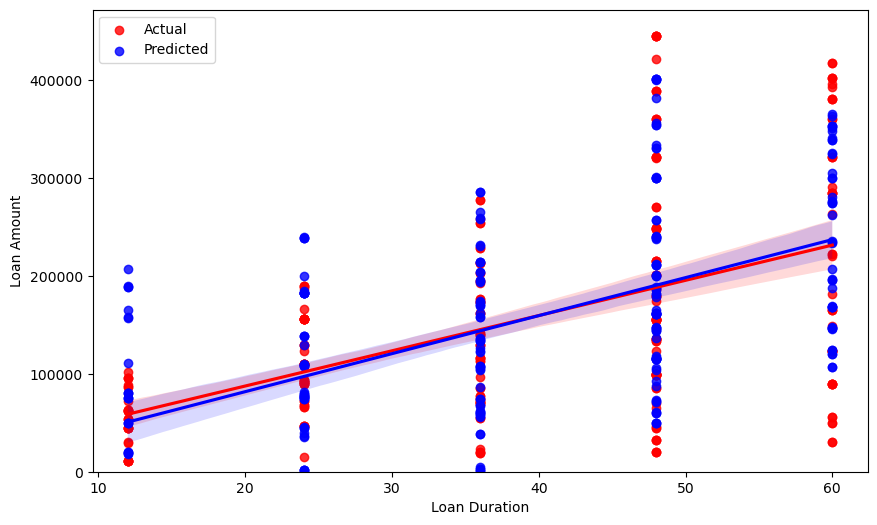

```python
# A scenario where you want to predict a client's loan amount based on their monthly transaction and loan information.

import pandas as pd
from sklearn.model_selection import train_test_split
from sklearn.linear_model import LinearRegression
from sklearn.metrics import mean_squared_error, r2_score
import matplotlib.pyplot as plt_solution5
import seaborn as sns

# Selecting features and target variable
# The features selected for the model are financially significant:
# Loan Duration: It indicates the term of the loan, which is directly related to the risk and amount of the loan, as longer loans generally involve larger amounts and potentially more risk.
# Average Transaction Amount: This reflects the customer's financial activity and turnover. Higher transaction amounts may indicate a customer's ability to manage and repay larger loans.
# Loan Payments: The regularity and amount of loan payments can provide insights into a customer's reliability and financial health, which are critical for assessing their risk profile.
# These features are indicative of a customer's financial behavior, creditworthiness, and capacity to service a loan, making them relevant for predicting loan amounts and assessing risk.
features = ['loan_duration', 'avg_trans_amount', 'loan_payments']
target = 'loan_amount'

X = newDF[features]
y = newDF[target]

# Splitting the data into training and testing sets
X_train, X_test, y_train, y_test = train_test_split(X, y, test_size=0.2, random_state=42)

# Creating and training the Linear Regression model
model = LinearRegression()
model.fit(X_train, y_train)

# Making predictions on the test set
predictions = model.predict(X_test)

# Evaluating the model
mse = mean_squared_error(y_test, predictions)
r2 = r2_score(y_test, predictions)

print(f'Mean Squared Error: {mse:.2f}')
print(f'R-squared: {r2:.2f}')

# Visualizing the results using Seaborn regplot
plt_solution5.figure(figsize=(10, 6))
sns.regplot(x=X_test['loan_duration'], y=y_test, color='red', label='Actual')
sns.regplot(x=X_test['loan_duration'], y=predictions, color='blue', label='Predicted')

plt_solution5.xlabel('Loan Duration')
plt_solution5.ylim(0)
plt_solution5.ylabel('Loan Amount')
plt_solution5.legend()
plt_solution5.show()
```